# GLMs Lab: Count & Proportion Data

### A3. Negative Binomial GLM & comparison

**Task.**

Fit a Negative Binomial GLM and compare to Poisson using AIC. Prefer NB if it provides a better likelihood-penalised fit.

**Your Mission**

*Step 1*: Fit a Negative Binomial GLM

Use the `glm.nb()` function to fit a negative binomial model that explicitly accounts for overdispersion by estimating a dispersion parameter.

*Step 2*: Examine the model summary

Review the coefficient estimates, standard errors, and the estimated theta (dispersion) parameter to understand how NB differs from Poisson.

*Step 3*: Compare models using AIC

Calculate AIC values for both Poisson and Negative Binomial models to determine which provides better model fit penalized for complexity.

*Step 4*: Make an informed model choice

Select the preferred model based on AIC comparison and biological interpretability of results.

```r
library(MASS)  # Required for glm.nb()

m_nb <- glm.nb(TOT.N ~ OPEN.L + D.PARK + L.WAT.C,
              data = datC)
summary(m_nb) # much lower residual deviance!!!!
```

```
##
## Call:
## glm.nb(formula = TOT.N ~ OPEN.L + D.PARK + L.WAT.C, data = datC,
##     init.theta = 4.018319601, link = log)
##
## Coefficients:
##               Estimate Std. Error z value Pr(>|z|)
## (Intercept)  1.206e+00  1.040e-01  11.596  < 2e-16 ***
## OPEN.L      -9.741e-03  1.182e-03  -8.242  < 2e-16 ***
## D.PARK      -1.322e-04  2.369e-05  -5.581 2.39e-08 ***
## L.WAT.C      1.857e-01  2.301e-02   8.071 6.96e-16 ***
## ---
## Signif. codes:  0 '***' 0.001 '**' 0.01 '*' 0.05 '.' 0.1 ' ' 1
##
## (Dispersion parameter for Negative Binomial(4.0183) family taken to be 1)
##
##     Null deviance: 844.04  on 599  degrees of freedom
## Residual deviance: 677.75  on 596  degrees of freedom
## AIC: 2359.4
##
## Number of Fisher Scoring iterations: 1
##
##
##               Theta:  4.018
##           Std. Err.:  0.638
##
##  2 x log-likelihood:  -2349.431
```

```r
# Compare models using AIC
AIC(m_pois, m_nb)
```

```
##        df      AIC
## m_pois  4 2445.521
## m_nb    5 2359.431
```

**Questions**

1. **Theta parameter**: What is the estimated theta ($\theta$) value in your negative binomial model? How does this compare to the true value ($\theta = 4$) used in your simulation?

2. **Standard errors**: Compare the standard errors between the Poisson and Negative Binomial models. Which model has larger standard errors and why?

3. **AIC comparison**: Which model has the lower AIC value? What does this tell you about model fit?

*NB, this model is better than poisson*

4. **Coefficient interpretation**: Are the coefficient signs and magnitudes similar between Poisson and NB models? What does this suggest about the robustness of your ecological conclusions?

*all of them are pretty small? I don’t know what that means.*

5. **Model choice**: Based on your AIC comparison, which model would you choose for inference and why?

*Nb due to residual deviance is smaller, AIC is smaller than poisson*

6. **Practical implications**: How might using the wrong model (Poisson vs. NB) affect your conclusions about which environmental factors significantly influence bird abundance?

*they are not too different, so it would proabbly not matter very much in this case*

### A4. Model simplification (drop-one, stepAIC)

**Task.**

Simplify the NB model: inspect drop-one Chi-square tests, then apply stepAIC to seek a parsimonious model.

**Your Mission**

*Step 1: Conduct drop-one tests*

Use `drop1()` with Chi-square tests to evaluate the individual contribution of each predictor when removed from the full model.

*Step 2: Apply automated model selection*

Use `stepAIC()` to systematically search for the most parsimonious model by comparing AIC values across different predictor combinations.

*Step 3: Examine the final simplified model*

Review the summary of the selected model to understand which predictors were retained and their statistical significance.

*Step 4: Interpret coefficients on the natural scale*

Transform log-scale coefficients to rate ratios (multiplicative effects) for easier ecological interpretation.

```r
# Step 1: Perform drop-one Chi-square tests
drop1(m_nb, test = "Chisq")    # Test individual predictor contributions
```

```
## Single term deletions
##
## Model:
## TOT.N ~ OPEN.L + D.PARK + L.WAT.C
##         Df Deviance    AIC    LRT  Pr(>Chi)
## <none>       677.75 2357.4
## OPEN.L   1   746.50 2424.2 68.747 < 2.2e-16 ***
## D.PARK   1   708.79 2386.5 31.037 2.532e-08 ***
## L.WAT.C  1   744.01 2421.7 66.260 3.951e-16 ***
## ---
## Signif. codes:  0 '***' 0.001 '**' 0.01 '*' 0.05 '.' 0.1 ' ' 1
```

```r
# Step 2: Apply stepwise AIC model selection

m_nb_step <- stepAIC(m_nb, trace = FALSE)    # Find most parsimonious model
                                          # trace = FALSE suppresses output

# Step 3: Examine the simplified model
summary(m_nb_step)    # Review final model structure and significance
```

```
##
## Call:
## glm.nb(formula = TOT.N ~ OPEN.L + D.PARK + L.WAT.C, data = datC,
##     init.theta = 4.018319601, link = log)
##
## Coefficients:
##               Estimate Std. Error z value Pr(>|z|)
## (Intercept)  1.206e+00  1.040e-01  11.596  < 2e-16 ***
## OPEN.L      -9.741e-03  1.182e-03  -8.242  < 2e-16 ***
## D.PARK      -1.322e-04  2.369e-05  -5.581 2.39e-08 ***
## L.WAT.C      1.857e-01  2.301e-02   8.071 6.96e-16 ***
## ---
## Signif. codes:  0 '***' 0.001 '**' 0.01 '*' 0.05 '.' 0.1 ' ' 1
##
## (Dispersion parameter for Negative Binomial(4.0183) family taken to be 1)
##
##     Null deviance: 844.04  on 599  degrees of freedom
## Residual deviance: 677.75  on 596  degrees of freedom
## AIC: 2359.4
##
## Number of Fisher Scoring iterations: 1
##
##
##               Theta:  4.018
##           Std. Err.:  0.638
##
##  2 x log-likelihood:  -2349.431
```

```r
# Step 4: Calculate rate ratios (multiplicative effects)
exp(coef(m_nb_step))    # Transform coefficients to natural scale
```

```
## (Intercept)      OPEN.L      D.PARK     L.WAT.C
##   3.3403668   0.9903065   0.9998678   1.2041173
```

```r
                  # exp() converts log-effects to multiplicative effects
```

**Questions**

## Interpretation Questions

1. **Drop-one results**: Which predictor(s) show the highest Chi-square values in the drop-one test? What does this indicate about their importance?

2. **Model selection outcome**: Did stepAIC retain all three predictors, or was the model simplified? Which variables (if any) were dropped?

*yes, kept everything*

3. **AIC improvement**: Compare the AIC of the final stepped model with the original full model. Is there evidence that simplification improved the model?

*almost the same. no evidence that it was improved*

4. **Rate ratio interpretation**: Looking at the `exp(coef())` output, how do you interpret the multiplicative effects? For example, what happens to bird abundance for every 1% increase in open land?

5. **Ecological significance**: Which environmental factor has the strongest multiplicative effect on bird abundance? How would you translate this into management recommendations?

*Strongest ecological effect: L.WAT.C. Management recommendation: Protect and expand wetlands/water habitats to promote bird abundance. Minimize conversion to open, unvegetated land.*

6. **Statistical vs. biological significance**: Are all retained predictors both statistically significant (p < 0.05) and ecologically meaningful? How do you distinguish between the two?

*All predictors are statistically highly significant (p < 0.001). Biological meaning differs, e.g. D.PARK’s per-meter effect is tiny, but could be ecologically relevant at larger spatial scales.*

### A5. Predictions (response scale) & CI plot

**Task.**

Produce fitted means and 95% confidence bands on the response scale for a key covariate (hold others at medians); plot observed counts + fitted curve.

**Your Mission**

*Step 1: Create a prediction grid*

Generate a sequence of values for your focal predictor (`OPEN.L`) while holding other predictors at their median values to isolate the effect of interest.

*Step 2: Generate model predictions*

Use the simplified model to predict bird counts across the range of open land percentages, including standard errors for uncertainty quantification.

*Step 3: Transform predictions to response scale*

Convert log-scale predictions and confidence intervals back to the count scale for meaningful interpretation.

*Step 4: Create a publication-ready plot*

Combine observed data points with model predictions and confidence bands to visualize the relationship.

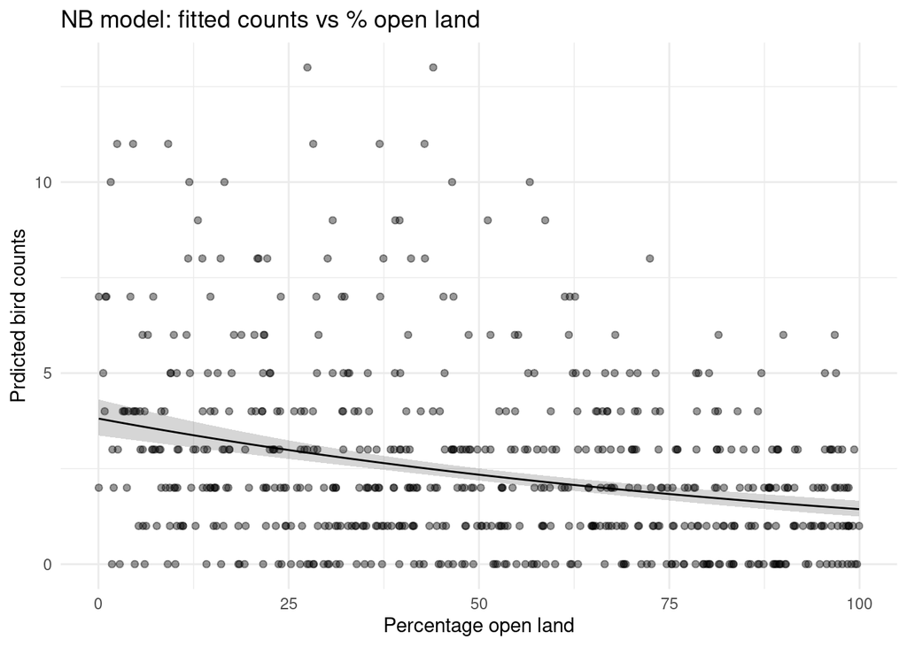

```r
# Step 1: Create prediction grid for focal variable
gridC <- tibble(
  OPEN.L = seq(min(datC$OPEN.L), max(datC$OPEN.L), length.out = 300),  # Sequence of 300 elements from min to max OPEN.L
  D.PARK = median(datC$D.PARK),                                        # Hold D.PARK at median value
  L.WAT.C = median(datC$L.WAT.C, na.rm = TRUE)                       # Hold L.WAT.C at median value
)

# Step 2: Generate predictions with standard errors
pl <- predict(m_nb_step, newdata = gridC, type = "link", se.fit = TRUE)        # Get link-scale predictions + SEs
                                                                      # type = "link" gives log-scale
                                                                      # se.fit = TRUE includes SEs

# Step 3: Transform to response scale with confidence intervals
gridC <- gridC |>
  mutate(
    mu = exp(pl$fit),                           # Transform fitted values to count scale
    lo = exp(pl$fit - 1.96*pl$se.fit),        # Lower 95% CI boundary
    hi = exp(pl$fit + 1.96*pl$se.fit)         # Upper 95% CI boundary
  )

# Step 4: Create the prediction plot
ggplot(datC, aes(x=OPEN.L, y=TOT.N)) +                                         # Plot original data
  geom_point(alpha = 0.4) +                                          # Add semi-transparent points
  geom_ribbon(data = gridC, aes(x = OPEN.L, ymin = lo, ymax = hi),
              alpha = 0.2,
              inherit.aes = FALSE) +                    # Add confidence band
  geom_line(data = gridC, aes(x = OPEN.L, y = mu),
            linewidth = 0.5, inherit.aes = FALSE) +                  # Add fitted line
  labs(title = "NB model: fitted counts vs % open land",
       x = "Percentage open land",
       y = "Prdicted bird counts") +                                # Add informative labels
  theme_minimal()
```

**Questions**

1. **Prediction grid setup**: Why do we hold D.PARK and L.WAT.C at their median values when creating predictions for OPEN.L? What would happen if we used different values?

2. **Link vs. response scale**: Why do we first predict on the “link” scale and then transform using `exp()`, rather than predicting directly on the response scale?

3. **Confidence interval interpretation**: What do the confidence bands around the fitted line represent? How would you explain this to a non-statistician?

4. **Ecological pattern**: Describe the relationship between open land percentage and bird counts shown in your plot. Does this match your biological expectations?

5. **Model fit assessment**: Looking at how well the fitted line and confidence bands capture the observed data points, would you say this model provides a good fit? What might you look for to assess this?

6. **Practical applications**: How could you use this plot to inform urban planning decisions about bird conservation?

### A6. Diagnostics: residuals & influence

**Task.**

Inspect deviance/Pearson residuals vs fitted and influence diagnostics. Look for structure (misspecification) and high-leverage points.

**Your Mission**

*Step 1: Extract diagnostic measures*

Create a comprehensive dataset containing fitted values, residuals, and influence measures from your negative binomial model to assess model assumptions and identify problematic observations.

*Step 2: Create residuals vs fitted plot*

Plot deviance residuals against fitted values to check for patterns that might indicate model misspecification, non-linearity, or heteroscedasticity.

*Step 3: Examine influence diagnostics*

Create a leverage vs Cook’s distance plot to identify observations that have high influence on model parameters or are potential outliers.

*Step 4: Interpret diagnostic patterns*

Assess whether the model adequately captures the data structure and identify any observations requiring further investigation.

[figure not shown]

```r
# Step 1: Extract all diagnostic measures into a tibble
diag_nb <- tibble(
  fitted  = fitted(m_nb),                          # Extract fitted values (predicted means)
  devres  = residuals(m_nb, type = "response"),         # Extract deviance residuals
  pearson = residuals(m_nb, type = "pearson"),         # Extract Pearson residuals
  hat     = hatvalues(m_nb),                       # Extract leverage values (diagonal of hat matrix)
  cooks   = cooks.distance(m_nb)                   # Extract Cook's distance (influence measure)
)

# Step 2: Create deviance residuals vs fitted values plot
ggplot(diag_nb, aes(x=fitted, y=devres)) +                      # Plot fitted vs deviance residuals
  geom_hline(yintercept = 0, linetype = "dashed") +  # Add horizontal reference line at y=0 (dashed)
  geom_point(alpha = 0.5) +                       # Add semi-transparent points (0.5)
  geom_smooth(se = TRUE) +                         # Add smooth trend line without confidence bands
  labs(title = "NB model: deviance residuals vs fitted",
       x = "Fitted values",
       y = "Deviance residuals") +                               # Add descriptive labels
  theme_minimal()
```

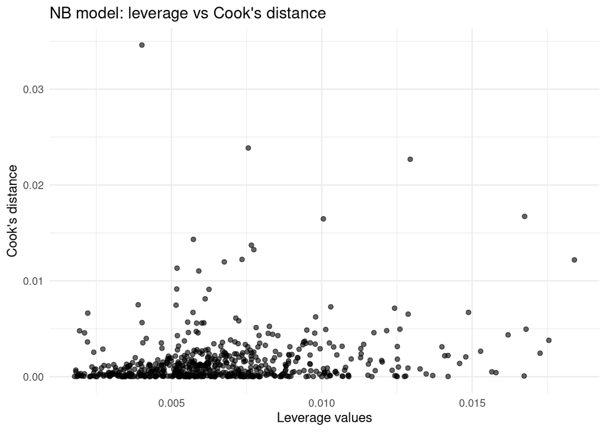

```r
# Step 3: Create leverage vs Cook's distance plot
ggplot(diag_nb, aes(x=hat, y=cooks)) +                      # Plot leverage vs Cook's distance
  geom_point(alpha = 0.6) +                       # Add semi-transparent points (0.6)
  labs(title = "NB model: leverage vs Cook's distance",
       x = "Leverage values",
       y = "Cook's distance") +                               # Add descriptive labels
  theme_minimal()
```

**Questions**

1. **Residual types**: What’s the difference between deviance and Pearson residuals, and why might we prefer deviance residuals for GLM diagnostics?

*Pearson tells you how many “standard deviations” each observation is from the fitted mean. Deviance residuals measure how much each observation contributes to the model deviance and thereby directly relate to the likelihood that underlies GLMs, so they are the natural analogue of residuals in ordinary regression.* s 2. **Residuals vs fitted interpretation**: In your deviance residuals plot, what pattern would indicate a well-fitting model? What patterns would suggest problems?

3. **Reference line importance**: Why do we include a horizontal dashed line at y=0 in the residuals plot, and what does it represent?

4. **Leverage interpretation**: What does high leverage indicate about an observation, and why should we be concerned about high-leverage points?

5. **Cook’s distance threshold**: Cook’s distance measures overall influence. What general threshold is often used to identify potentially problematic observations, and why?

6. **Diagnostic integration**: How would you use both plots together to identify the most concerning observations? What would be the “worst case” combination of leverage and Cook’s distance?

7. **Model adequacy assessment**: Based on your diagnostic plots, would you conclude that the negative binomial GLM adequately fits your simulated data? What evidence supports this conclusion?